# W3cubDocs

## Examples using `matplotlib.axes.Axes.imshow`

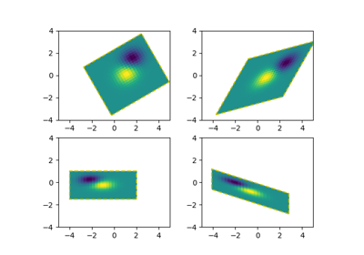

[Affine transform of an image](https://matplotlib.org/3.1.1/gallery/images_contours_and_fields/affine_image.html#sphx-glr-gallery-images-contours-and-fields-affine-image-py)

[figure not shown]

[Barcode Demo](https://matplotlib.org/3.1.1/gallery/images_contours_and_fields/barcode_demo.html#sphx-glr-gallery-images-contours-and-fields-barcode-demo-py)

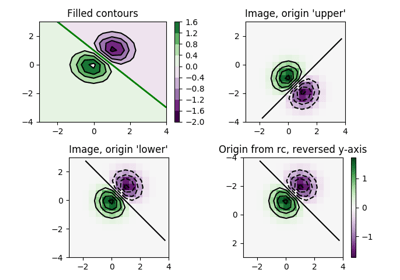

[Contour Image](https://matplotlib.org/3.1.1/gallery/images_contours_and_fields/contour_image.html#sphx-glr-gallery-images-contours-and-fields-contour-image-py)

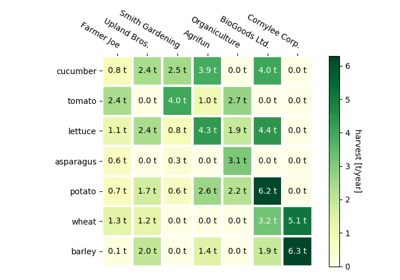

[Creating annotated heatmaps](https://matplotlib.org/3.1.1/gallery/images_contours_and_fields/image_annotated_heatmap.html#sphx-glr-gallery-images-contours-and-fields-image-annotated-heatmap-py)

[figure not shown]

[Clipping images with patches](https://matplotlib.org/3.1.1/gallery/images_contours_and_fields/image_clip_path.html#sphx-glr-gallery-images-contours-and-fields-image-clip-path-py)

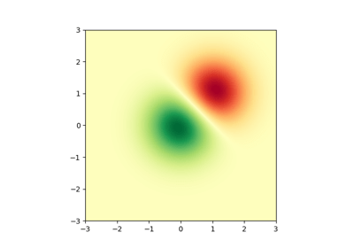

[Image Demo](https://matplotlib.org/3.1.1/gallery/images_contours_and_fields/image_demo.html#sphx-glr-gallery-images-contours-and-fields-image-demo-py)

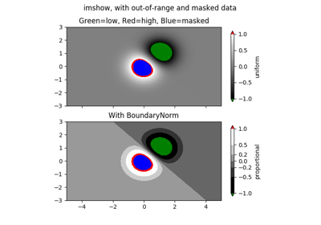

[Image Masked](https://matplotlib.org/3.1.1/gallery/images_contours_and_fields/image_masked.html#sphx-glr-gallery-images-contours-and-fields-image-masked-py)

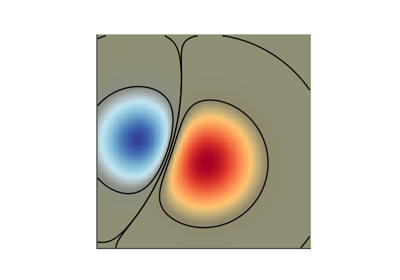

[Blend transparency with color in 2-D images](https://matplotlib.org/3.1.1/gallery/images_contours_and_fields/image_transparency_blend.html#sphx-glr-gallery-images-contours-and-fields-image-transparency-blend-py)

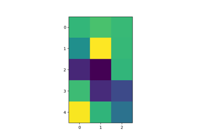

[Modifying the coordinate formatter](https://matplotlib.org/3.1.1/gallery/images_contours_and_fields/image_zcoord.html#sphx-glr-gallery-images-contours-and-fields-image-zcoord-py)

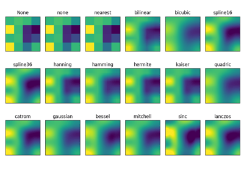

[Interpolations for imshow/matshow](https://matplotlib.org/3.1.1/gallery/images_contours_and_fields/interpolation_methods.html#sphx-glr-gallery-images-contours-and-fields-interpolation-methods-py)

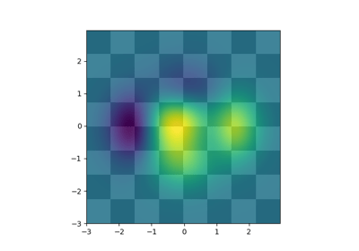

[Layer Images](https://matplotlib.org/3.1.1/gallery/images_contours_and_fields/layer_images.html#sphx-glr-gallery-images-contours-and-fields-layer-images-py)

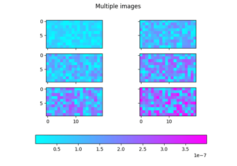

[Multi Image](https://matplotlib.org/3.1.1/gallery/images_contours_and_fields/multi_image.html#sphx-glr-gallery-images-contours-and-fields-multi-image-py)

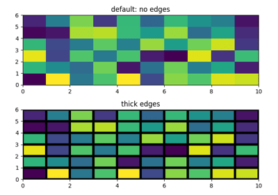

[Pcolor Demo](https://matplotlib.org/3.1.1/gallery/images_contours_and_fields/pcolor_demo.html#sphx-glr-gallery-images-contours-and-fields-pcolor-demo-py)

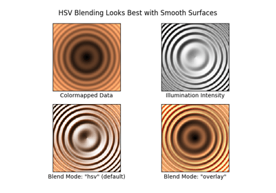

[Shading example](https://matplotlib.org/3.1.1/gallery/images_contours_and_fields/shading_example.html#sphx-glr-gallery-images-contours-and-fields-shading-example-py)

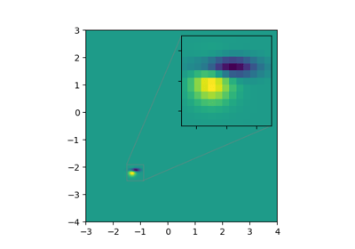

[Zoom region inset axes](https://matplotlib.org/3.1.1/gallery/subplots_axes_and_figures/zoom_inset_axes.html#sphx-glr-gallery-subplots-axes-and-figures-zoom-inset-axes-py)

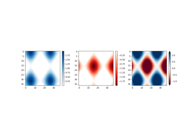

[Colorbar](https://matplotlib.org/3.1.1/gallery/color/colorbar_basics.html#sphx-glr-gallery-color-colorbar-basics-py)

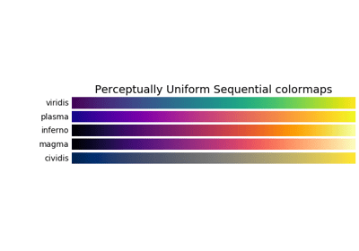

[Colormap reference](https://matplotlib.org/3.1.1/gallery/color/colormap_reference.html#sphx-glr-gallery-color-colormap-reference-py)

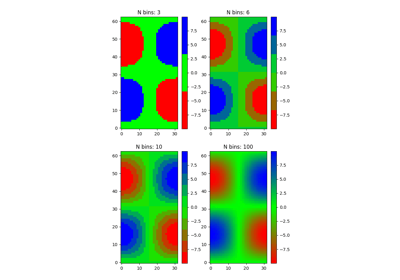

[Creating a colormap from a list of colors](https://matplotlib.org/3.1.1/gallery/color/custom_cmap.html#sphx-glr-gallery-color-custom-cmap-py)